# 1. Linear Time-Invariant (LTI) Systems

## 4.2. Response to a Periodic Input (in the Frequency Domain)

### 4.2.1. Periodic Signal and Harmonics

A signal is periodic if it satisfies:

$$x(t) = x(t + T) $$

where:

$$ \begin{align*} {\omega_0} &= 2\pi f \quad \text{is the fundamental frequency }\\ T &= \frac{2\pi}{\omega_0} \quad \;\text{is the fundamental period } \end{align*} $$

Periodic signals can be represented as an infinite sum of complex exponentials using the Fourier series.

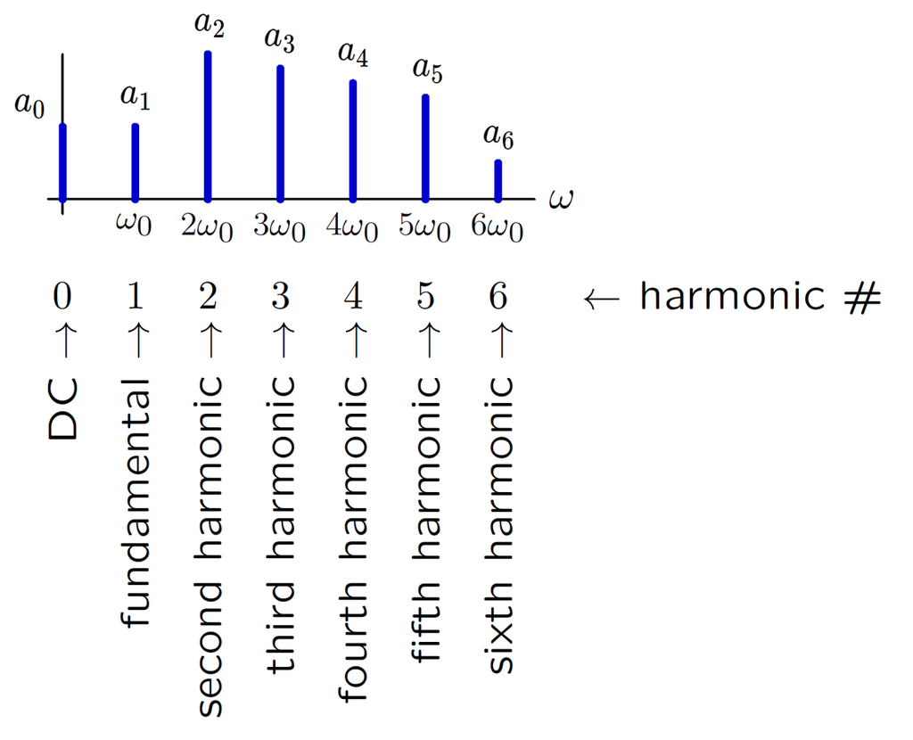

Fourier series

$$ \begin{align*} x(t) &= a_0 + a_1e^{j\omega_0t} + a_2e^{j2\omega_0t} + a_3e^{j3\omega_0t} + \cdots \\\\ &= \sum\limits^\infty_{k=-\infty}a_ke^{jk\omega_0t} \end{align*} $$

This representation decomposes the signal into harmonic components - sinusoids with frequencies that are integer multiples of the fundamental frequency.

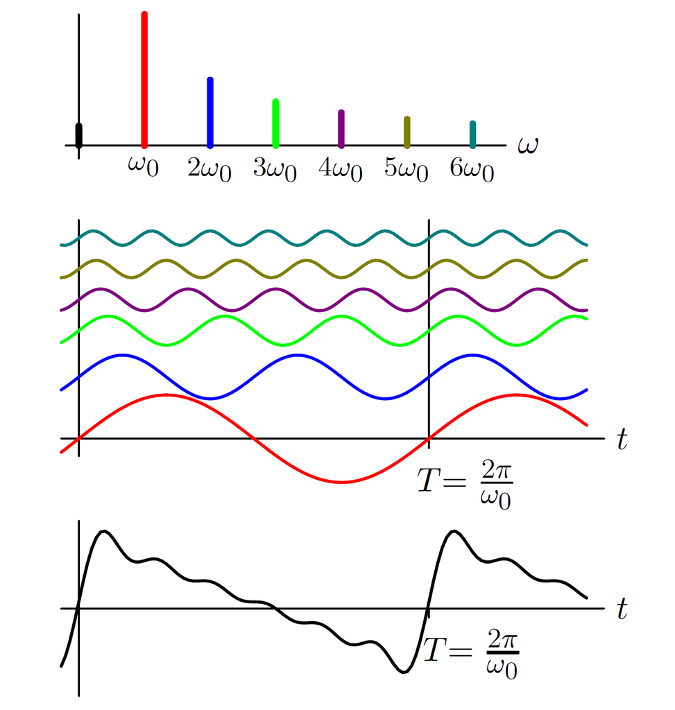

Let $\omega_0 = \frac{2\pi}{T}$ be the fundamental frequency. The complex exponentials $e^{jk\omega_0 t}$ are orthogonal over a period $T$:

$$ \int_t^{t+T} e^{jk_1\omega_0 \tau} \cdot e^{-jk_2\omega_0 \tau} \, d\tau = \begin{cases} 0 & \text{if } k_1 \ne k_2 \\ T & \text{if } k_1 = k_2 \end{cases} \quad \Rightarrow \quad T\delta[k_1 - k_2] $$

This orthogonality allows us to extract the $k$-th coefficient $a_k$ in a Fourier series.

**Fourier Series Expansion**

Assume $x(t)$ is periodic with period $T$:

$$ x(t) = \sum_{k=-\infty}^{\infty} a_k e^{j k \omega_0 t}, \qquad \omega_0 = \frac{2\pi}{T} $$

**Finding the Coefficients $a_k$**

Multiply both sides by $e^{-j n \omega_0 t}$ and integrate over one period:

$$ \begin{align*} \int_T x(t)e^{-jn\omega_0t}dt &= \int_T \sum\limits^\infty_{k=-\infty}a_ke^{jk\omega_0t} \cdot e^{-jn\omega_0t}dt \\\\ &= \sum\limits^\infty_{k=-\infty}a_k\int_T e^{j(k-n)\omega_0t}dt \\\\ &= a_nT \end{align*} $$

Thus:

$$ a_n = \frac{1}{T} \int_T x(t)e^{-j n \omega_0 t} dt $$

**Summary**

- Analysis (extracting $a_k$):

$$ a_k = \frac{1}{T} \int_T x(t) e^{-j k \omega_0 t} \, dt $$

- Synthesis (rebuilding $x(t)$):

$$ x(t) = \sum_{k=-\infty}^{\infty} a_k e^{j k \omega_0 t} $$

This framework applies to any periodic signal that meets Dirichlet conditions.

**Example**: Fourier Series of a Triangle Wave

The Fourier series expansion in complex exponential form is:

$$ x(t) = \sum_{\substack{k = -\infty \\ k \; \text{odd}}}^{\infty} \frac{-1}{2k^2\pi^2} e^{j 2\pi k t} $$

Alternatively, using the fundamental frequency $\omega_0 = 2\pi$, this becomes:

$$ x(t) = \sum_{\substack{k = -\infty \\ k \; \text{odd}}}^{\infty} \frac{-2}{\omega_0^2 k^2} e^{j \omega_0 k t} $$

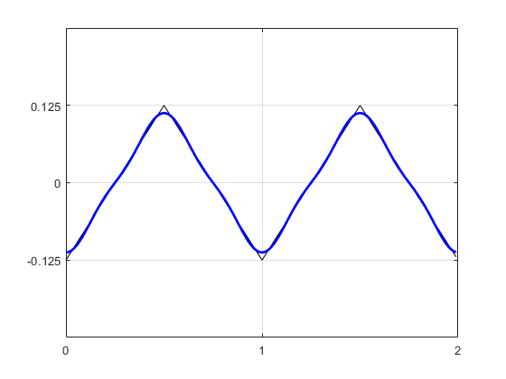

```matlab
T = 1;

fs = 100;
t = 0:1/fs:2*T-1/fs;

w0 = 2*pi/T;
x = 1/8*sawtooth(w0*t, 1/2);

% xhat = Fourier series of triangle ware
xhat = zeros(size(t));

for k = -3:2:3
    xhat = xhat - 2/(w0^2*k^2)*exp(1j*w0*k*t);
end

plot(t, x, 'k'), hold on
plot(t, xhat, 'b', 'linewidth', 2), hold off
grid on
ylim([-2/8,2/8])
xticks([0,1,2])
yticks([-1/8,0,1/8])
```

**Example**: Fourier Series of a Square Wave

Its Fourier series expansion in complex exponential form is:

$$ x(t) = \sum_{\substack{k = -\infty \\ k \; \text{odd}}}^{\infty} \frac{1}{jk\pi} e^{j 2\pi k t} $$

or equivalently using $\omega_0 = 2\pi$:

$$ x(t) = \sum_{\substack{k = -\infty \\ k \; \text{odd}}}^{\infty} \frac{2}{j\omega_0 k} e^{j \omega_0 k t} $$

Key Characteristics:

- Odd harmonics only: Square waves only contain odd multiples of the fundamental frequency due to odd symmetry and half-wave symmetry.
- Spectral decay: Coefficients decay as $1/k$, which means the signal has sharp transitions (discontinuities).
- Imaginary denominator: Indicates that when converted to sine-cosine form, the square wave becomes a sum of sines, since the imaginary parts of complex exponentials give sine functions.
- Real signal: Despite using complex exponentials, the result is real-valued due to the symmetry $a_{-k} = a_k^*$.

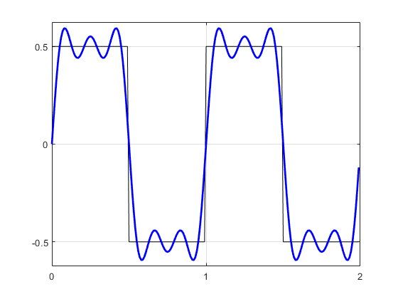

```matlab
T = 1;

fs = 100;
t = 0:1/fs:2*T-1/fs;

w0 = 2*pi/T;
x = 1/2*square(w0*t);

% xhat = Fourier series of square ware
xhat = zeros(size(t));

for k = -5:2:5
    xhat = xhat + 2/(1j*w0*k)*exp(1j*w0*k*t);
end

plot(t, x, 'k'), hold on
plot(t, xhat, 'b', 'linewidth', 2), hold off
grid on
ylim([-5/8,5/8])
xticks([0,1,2])
yticks([-1/2,0,1/2])
```

### 4.2.2. LTI System Response to Harmonic Inputs

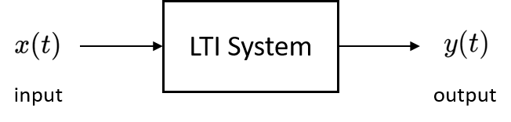

One of the most powerful properties of LTI systems is that complex exponentials are eigenfunctions. That is, for an input:

$$ x_k(t) = e^{j\omega_k t} $$

the output is:

$$ y_k(t) = H(j\omega_k) e^{j\omega_k t} $$

where $H(j\omega_k)$ is the system’s frequency response evaluated at frequency $\omega_k$.

Thus, for a general periodic input:

$$ x(t) = \sum_{k=-\infty}^{\infty} a_k e^{j\omega_0 k t} $$

the output is simply:

$$ y(t) = \sum_{k=-\infty}^{\infty} a_k H(j\omega_0 k) e^{j\omega_0 k t} $$

This is a filtered version of the input: each harmonic is scaled and phase-shifted according to the system's frequency response at that harmonic.

**Worked Example**: First-Order System

Consider the first-order LTI system:

$$ \dot{y} + \frac{1}{\tau} y = \frac{1}{\tau} x(t) $$

Let the input be a complex exponential:

$$ x(t) = e^{j\omega t} $$

We look for a steady-state solution of the form:

$$ y(t) = A e^{j(\omega t + \phi)} $$

Substituting into the ODE:

$$ \frac{d}{dt} \left(A e^{j(\omega t + \phi)}\right) + \frac{1}{\tau} A e^{j(\omega t + \phi)} = \frac{1}{\tau} e^{j\omega t} $$

yields:

$$ \left(j\omega + \frac{1}{\tau} \right) A e^{j\phi} = \frac{1}{\tau} $$

Solving for the amplitude and phase:

$$ A = |H(j\omega)| = \frac{1}{\sqrt{(\tau \omega)^2 + 1}}, \quad \phi = -\tan^{-1}(\tau \omega) $$

Thus, the frequency response is:

$$ H(j\omega) = \frac{1}{1 + j\tau\omega} $$

with magnitude and phase:

$$ |H(j\omega)| = \frac{1}{\sqrt{1 + (\tau\omega)^2}}, \qquad \angle H(j\omega) = -\tan^{-1}(\tau \omega) $$

**Interpretation**

- Each frequency component of a periodic signal is attenuated and phase-shifted by the system's response at that frequency.
- The output spectrum is a modulated version of the input spectrum.
- The system behaves like a filter, shaping the harmonic content of the signal.

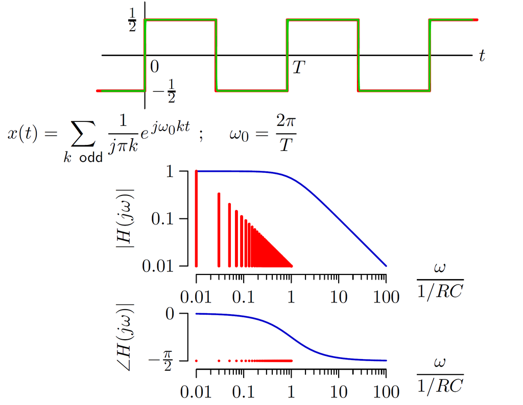

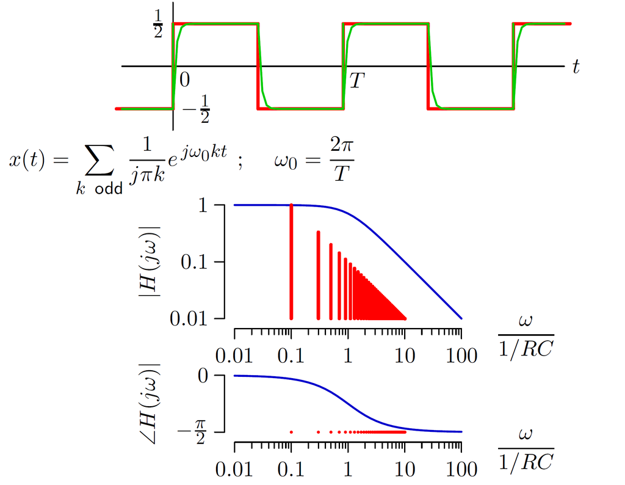

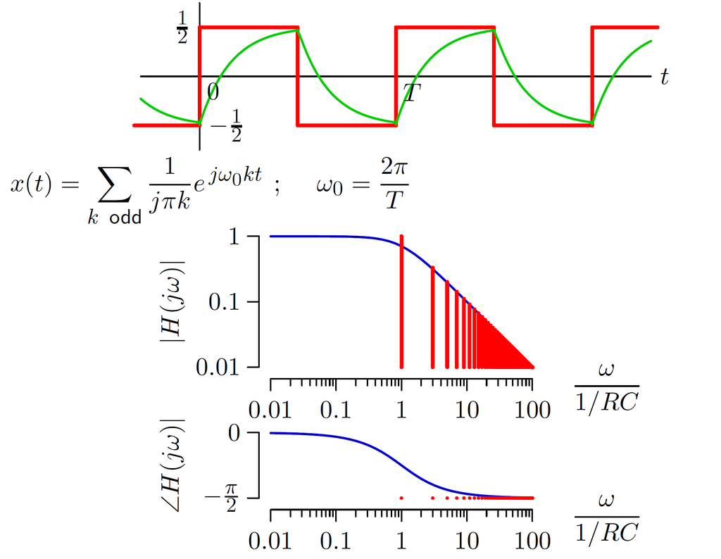

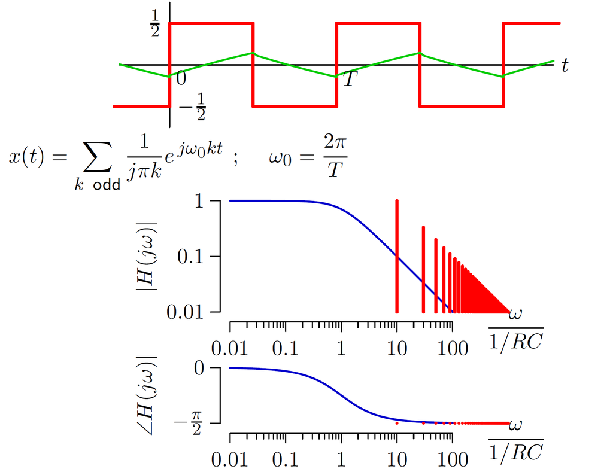

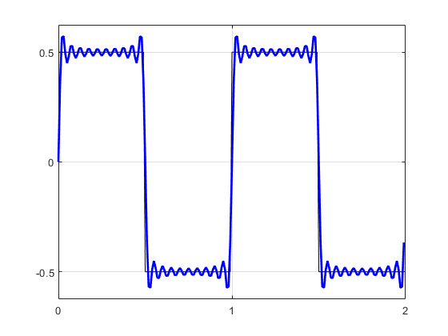

```matlab
T = 1;

fs = 100;
t = 0:1/fs:2*T-1/fs;

w0 = 2*pi/T;
x = 1/2*square(w0*t);

% xhat = Fourier series of square ware
xhat = zeros(size(t));

for k = -19:2:19
    xhat = xhat + 2/(1j*w0*k)*exp(1j*w0*k*t);
end

plot(t, x, 'k'), hold on
plot(t, xhat, 'b', 'linewidth', 2), hold off
grid on
ylim([-5/8,5/8])
xticks([0,1,2])
yticks([-1/2,0,1/2])
```

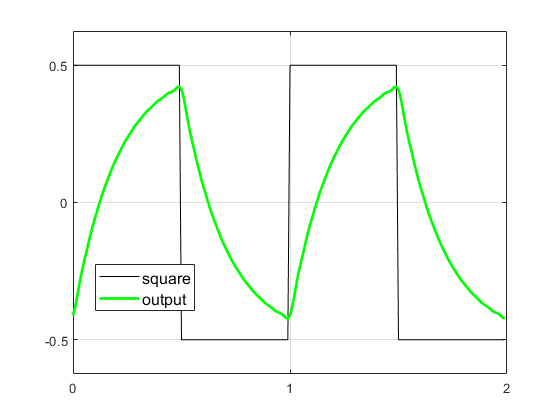

```matlab
tau = 1/5;

yhat = zeros(size(t));

for k = -19:2:19
    w = w0*k;
    A = 1./abs(1j*tau*w + 1);
    Ph = -phase(1j*tau*w + 1);
    yhat = yhat + A*2/(1j*w0*k)*exp(1j*(w*t + Ph));
end

plot(t, x, 'k'), hold on
plot(t, yhat, 'g', 'linewidth', 2), hold off
grid on
ylim([-5/8,5/8])
xticks([0,1,2])
yticks([-1/2,0,1/2])
leg = legend('square', 'output');
set(leg, 'fontsize', 12, 'location', 'best')
```

## 4.3. Response to a General Input (Aperiodic Signal) in Frequency Domain

**From Periodic to Aperiodic**

An aperiodic signal can be interpreted as a periodic signal with infinite period. That is:

$$x_T(t) = \sum\limits^\infty_{k=-\infty}x(t+kT)$$

$$x(t) = \lim\limits_{T\rightarrow \infty}x_T(t)$$

This periodic extension allows the use of Fourier series, which then transition to the Fourier transform as $T \to \infty$.

**Example**: Periodic Square Wave

Let a aperiodic signal be defined as:

$$ x(t) = \begin{cases} 1 & |t| < S \\ 0 & S < |t| < \frac{T}{2} \end{cases} $$

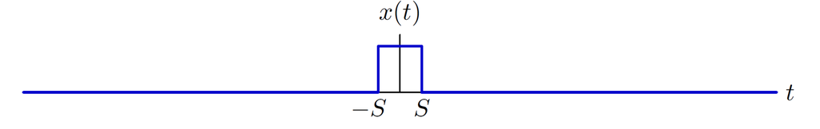

Then periodic extension to periodic square wave $x_T(t)$

$$x_T(t) = \sum\limits^\infty_{k=-\infty}x(t+kT)$$

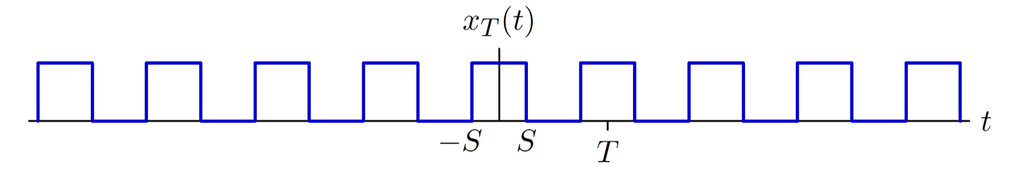

Then compute the Fourier series coefficients:

$$ \begin{align*} \omega_0 &= {2\pi \over T}\\\\ a_k &= {1 \over T} \int^{T \over 2}_{-T \over 2}x_T(t)e^{-j\omega_0kt}dt \\ &= {1 \over T} \bigg[\int^s_{-s}1 \cdot e^{-j\omega_0kt}dt \bigg] = {1 \over T}\bigg[-{e^{-j\omega_0kt} \over j\omega_0k} \bigg\rvert^s_{-s} \bigg] \\ &= -{1 \over T} \bigg[ {e^{-j\omega_0ks} \over j\omega_0k} - {e^{j\omega_0ks} \over j\omega_0k} \bigg] = {1 \over T} \bigg[{-2 \over j\omega_0k} \cdot {{e^{-j\omega_0ks} - e^{j\omega_0ks}} \over 2} \bigg] \\ &= {1 \over T} {-2 \over j \omega_0 k}(-j \sin (\omega_0 k s)) = {1 \over T}{2\sin (\omega_0 k s) \over \omega_0 k} \\ &= {2 \over T} {\sin(\omega_0 k s) \over \omega_0k} \end{align*} $$

Multiply by $T$ to isolate the spectral content:

$$ T a_k = \frac{2 \sin(\omega_0 k s)}{\omega_0 k} $$

Let $\omega = \omega_0 k$, then:

$$ T a_k = \frac{2 \sin(\omega s)}{\omega} $$

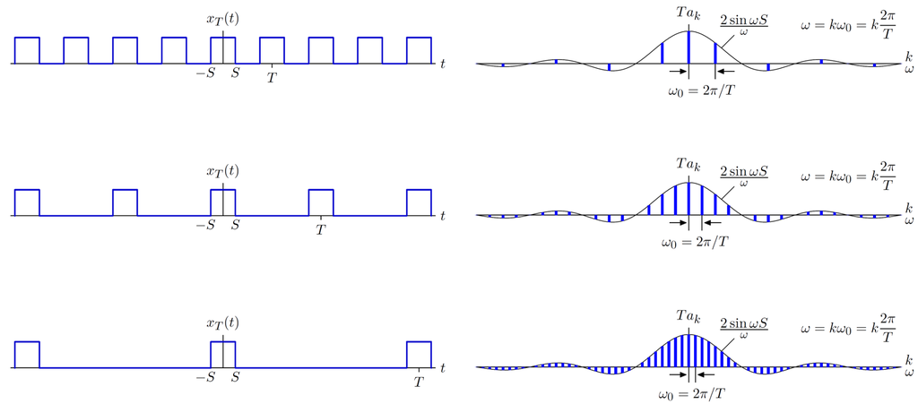

**Limit as $T \to \infty$**

As the period $T$ becomes infinite:

- The fundamental frequency $\omega_0 = \frac{2\pi}{T} \to 0$
- The discrete set of harmonic frequencies becomes dense, forming a continuum
- The scaled coefficients $T a_k$ approach the continuous Fourier transform:

$$ \lim_{T \to \infty} T a_k = X(j\omega) = \int_{-\infty}^\infty x(t) e^{-j\omega t} dt $$

For the square pulse:

$$ X(j\omega) = \frac{2 \sin(\omega s)}{\omega} $$

This is the well-known sinc-shaped spectrum of a rectangular pulse.

**Summary**

- Periodic signal → sum of discrete harmonics via Fourier series
- Aperiodic signal → continuous frequency spectrum via Fourier transform
- As $T \to \infty$, the discrete coefficients $a_k$ become samples of an envelope function:

$$ T a_k \to X(j\omega) = \frac{2 \sin(\omega s)}{\omega} $$

$$Ta_k = {2\text{sin} \omega s \over \omega} \bigg\rvert_{\omega=k\omega_0}$$

- That is, with $\omega$ thought of as a continuous variable, the set of Fourier series coefficients approaches the envelop function as $T \rightarrow \infty$
- Aperiodic signal has all the frequency components instead of discrete harmonic components
- The Fourier series becomes a Fourier transform:

$$ x(t) = \sum_k a_k e^{j \omega_0 k t} \quad \to \quad x(t) = \frac{1}{2\pi} \int_{-\infty}^{\infty} X(j\omega) e^{j \omega t} d\omega $$

This forms the foundation for analyzing arbitrary signals and their behavior in LTI systems using frequency response.

# 5. Fourier Transform

**From Periodic to Aperiodic**

As the period $T \to \infty$, the discrete frequencies $\omega_0 = \frac{2\pi}{T}$ become infinitely close, turning the summation into an integral:

$$ \begin{align*} x(t) &= \sum_{k=-\infty}^{\infty} a_k e^{j\omega_0 k t} \\\\ &= \sum_{k=-\infty}^{\infty} \frac{X(j\omega_0 k)}{T} e^{j\omega_0 k t} \\\\ &= \frac{1}{2\pi} \sum_{k=-\infty}^{\infty} X(j\omega_0 k) e^{j\omega_0 k t} \, \omega_0 \\\\ &\to \frac{1}{2\pi} \int_{-\infty}^{\infty} X(j\omega) e^{j\omega t} d\omega \quad \text{as } \; \;T \to \infty \end{align*} $$

**Fourier Transform Pair**

This leads to the Fourier Transform, which maps time-domain signals into the frequency domain:

Analysis (forward transform):

$$ X(j\omega) = \int_{-\infty}^{\infty} x(t) e^{-j\omega t} dt $$

Synthesis (inverse transform):

$$ x(t) = \frac{1}{2\pi} \int_{-\infty}^{\infty} X(j\omega) e^{j\omega t} d\omega $$

**Response of LTI Systems in Frequency Domain**

Given an LTI system with impulse response $h(t)$ and input $x(t)$:

(1) Time-domain:

$$y(t) = x(t) * h(t)$$

(2) Frequency-domain:

$$ \mathscr{F}\{y(t)\} = \mathscr{F}\{x(t)*h(t)\} = X(j\omega)H(j\omega) $$

So,

$$ y(t) = \frac{1}{2\pi} \int_{-\infty}^{\infty} X(j\omega)H(j\omega) e^{j\omega t} d\omega $$

**Summary**

- Fourier Series: for periodic signals
- Fourier Transform: for aperiodic signals
- LTI system response is multiplication in frequency domain:

$$ y(t) = x(t) * h(t) \quad \Longleftrightarrow \quad Y(j\omega) = X(j\omega) H(j\omega) $$

This is a cornerstone of signal processing and control theory.

## 5.1. Impulse Response

The impulse response $h(t)$ fully characterizes a linear time-invariant (LTI) system. It is the output of the system when the input is a Dirac delta function $\delta(t)$:

$$ \delta(t) \quad \mathop\longrightarrow^{\text{LTI}} \quad h(t) $$

**Fourier Transform of the Delta Function**

The Dirac delta function has a very special Fourier transform:

$$ \int_{-\infty}^{\infty} \delta(t) e^{-j\omega t} dt = 1 $$

So,

$$ \delta(t) \quad \longleftrightarrow \quad 1 \quad \text{(in frequency domain)} $$

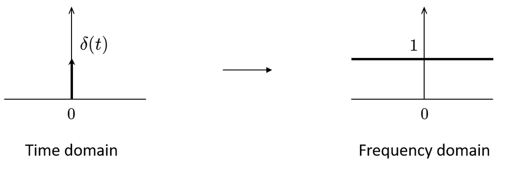

This means $\delta(t)$ contains all frequencies equally, with unit magnitude and zero phase shift.

**Why Impulse Response is Powerful**

- Excitation by all frequencies: Since $\delta(t)$ contains all frequencies, applying it to an LTI system "probes" the system's response at every frequency.
- Impulse basically excites a system with all the frequency of $𝑒^{𝑗\omega 𝑡}$
- Time domain: $h(t)$ describes how the system reacts over time.
- Frequency domain: Its Fourier transform $H(j\omega)$ tells how each frequency is:
  - Scaled (magnitude response $\lvert H(j\omega) \rvert$)
  - Shifted (phase response $\angle H(j\omega)$)

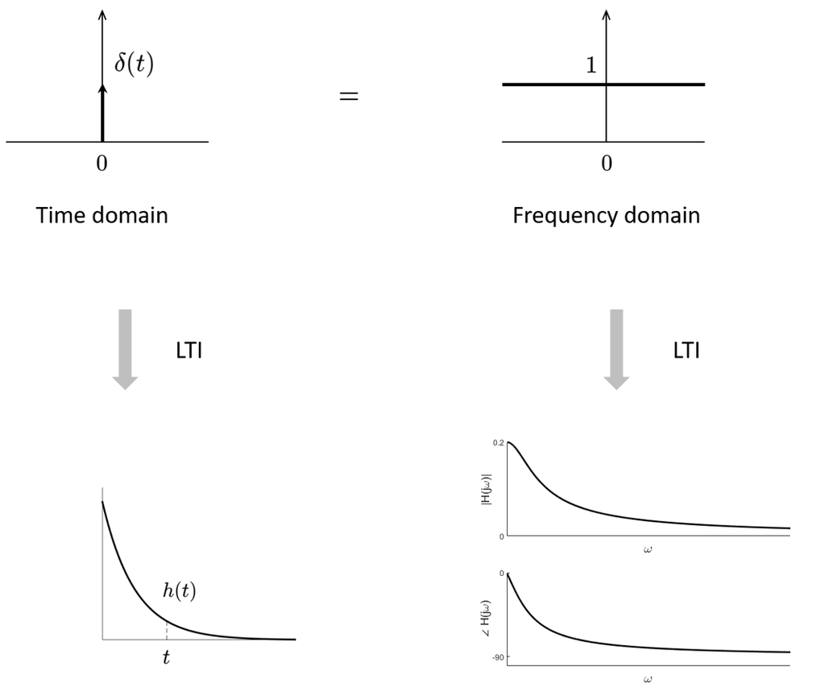

**Summary**

Impulse response is the most fundamental descriptor of an LTI system both in time and frequency.

- Impulse response $h(t)$ $\leftrightarrow$ frequency response $H(j\omega)$
- $H(j\omega)$ tells us how the system filters sinusoidal components of any input
- Impulse response contains the information on how much magnitude and phase are filtered via the LTI system at all the frequency
- The convolution $y(t) = h(t) * x(t)$ in time is equivalent to multiplication in frequency:

$$ x(t) * h(t) \quad \longleftrightarrow \quad X(j\omega) \cdot H(j\omega) $$

## 5.2. Frequency Response (Frequency Sweep)

A frequency sweep is another way to characterize an LTI system - equivalent in information to the impulse response, but presented in the frequency domain.

Suppose we input a complex exponential at a single frequency:

$$ x(t) = e^{j\omega t} $$

and consider the LTI system:

$$ \dot{y} + 5y = 5x(t) $$

Substituting the input:

$$ \dot{y} + 5y = 5e^{j\omega t} $$

Assume the output has the same frequency as the input (because LTI systems do not create new frequencies):

$$ y(t) = A e^{j(\omega t + \phi)} = A e^{j\omega t} e^{j\phi} $$

Take the derivative:

$$ \dot{y}(t) = j\omega A e^{j\omega t} e^{j\phi} $$

Substitute into the differential equation:

$$ (j\omega + 5) A e^{j\omega t} e^{j\phi} = 5 e^{j\omega t} $$

Cancel $e^{j\omega t}$ from both sides:

$$ (j\omega + 5) A e^{j\phi} = 5 $$

Take the magnitude:

$$ A = \frac{5}{|j\omega + 5|} = \frac{5}{\sqrt{\omega^2 + 25}} $$

Take the phase:

$$ \phi = -\angle(j\omega + 5) = -\tan^{-1}\left( \frac{\omega}{5} \right) $$

**Frequency Response**

The frequency response of the system is:

$$ H(j\omega) = \frac{5}{j\omega + 5} $$

- Magnitude response:

$$ |H(j\omega)| = \frac{5}{\sqrt{\omega^2 + 25}} $$

- Phase response:

$$ \angle H(j\omega) = -\tan^{-1} \left( \frac{\omega}{5} \right) $$

**Summary**

By sweeping over $\omega$ and observing the amplitude and phase of the output, we obtain:

- The gain at each frequency: how much the system amplifies or attenuates each frequency
- The phase shift at each frequency: how the output is delayed or advanced relative to the input

This is precisely the frequency response $H(j\omega)$ of the LTI system.

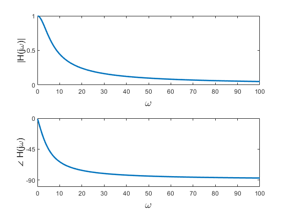

```matlab
w = 0.1:0.1:100;

A = 5./abs(1j*w+5);
P = -angle(1j*w+5)*180/pi;

subplot(2,1,1), plot(w, A, 'linewidth', 2)
yticks([0,0.5,1])
ylabel('|H(j\omega)|', 'fontsize', 13)
xlabel('\omega', 'fontsize', 15)

subplot(2,1,2), plot(w, P, 'linewidth', 2)
yticks([-90, -45, 0])
ylabel('\angle H(j\omega)', 'fontsize', 13)
xlabel('\omega', 'fontsize', 15)

% later, we will see that this is kind of a bode plot
```

## 5.3. Frequency Response of a Second-Order System

Consider the second-order ODE:

$$ \ddot{y} + 2\zeta\omega_n\dot{y} + \omega_n^2 y = \omega_n^2 \; x(t) $$

We input a complex exponential:

$$ x(t) = e^{j\Omega t} $$

The differential equation becomes:

$$ \ddot{y} + 2\zeta\omega_n\dot{y} + \omega_n^2 y = \omega_n^2 \; e^{j\Omega t} $$

(1) Step 1: Assume the Steady-State Output

Because $x(t)$ is a complex exponential and LTI systems preserve frequency:

$$ y(t) = A e^{j(\Omega t + \phi)} = A e^{j\phi} e^{j\Omega t} $$

(2) Step 2: Substitute into the Differential Equation

Take derivatives:

$$ \dot{y} = j\Omega A e^{j\phi} e^{j\Omega t}, \qquad \ddot{y} = -\Omega^2 A e^{j\phi} e^{j\Omega t} $$

Substitute into the ODE:

$$ \left( -\Omega^2 + j 2\zeta \omega_n \Omega + \omega_n^2 \right) A e^{j\phi} e^{j\Omega t} = \omega_n^2 e^{j\Omega t} $$

Cancel $e^{j\Omega t}$:

$$ A e^{j\phi} = \frac{\omega_n^2}{-\Omega^2 + j 2\zeta \omega_n \Omega + \omega_n^2} = \frac{1}{1-\left(\frac{\Omega}{\omega_n}\right)^2 + j 2\zeta \left(\frac{\Omega}{\omega_n}\right)} $$

(3) Step 3: Express in Terms of Frequency Ratio $\gamma = \frac{\Omega}{\omega_n}$

The magnitude (gain) becomes:

$$ A = \left| \frac{1}{1 - \left( \frac{\Omega}{\omega_n} \right)^2 + j 2\zeta \left( \frac{\Omega}{\omega_n} \right)} \right| = \frac{1}{ \sqrt{ \left(1 - \gamma^2 \right)^2 + 4\zeta^2 \gamma^2 } } $$

The phase shift is:

$$ \phi = -\tan^{-1} \left( \frac{2\zeta \frac{\Omega}{\omega_n}}{1-\left(\frac{\Omega}{\omega_n}\right)^2} \right) =-\tan^{-1} \left( \frac{2\zeta \gamma}{1-\gamma^2} \right) $$

**Summary**

For the second-order system with input $x(t) = e^{j\Omega t}$:

- Frequency ratio: $\gamma = \frac{\Omega}{\omega_n}$
- Amplitude response (gain):

$$ |H(j\Omega)| = \frac{1}{ \sqrt{ (1 - \gamma^2)^2 + 4\zeta^2 \gamma^2 } } $$

- Phase response:

$$ \angle H(j\Omega) = -\tan^{-1} \left( \frac{2\zeta \gamma}{1 - \gamma^2} \right) $$

This is the standard frequency response of a damped second-order system.

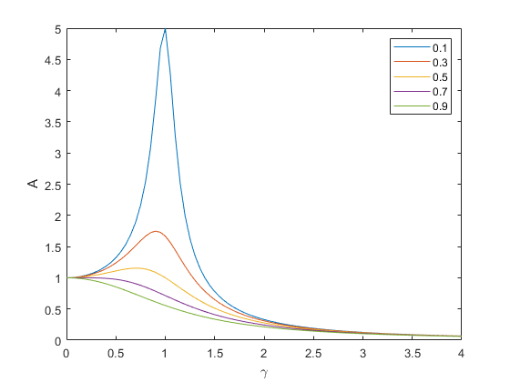

```matlab
r = 0:0.05:4;

zeta = 0.1:0.2:1;
A = [];
for i = 1:length(zeta)
    A(i,:) = 1./sqrt((1-r.^2).^2 + (2*zeta(i)*r).^2);
end

plot(r, A)
xlabel('\gamma')
ylabel('A')
legend('0.1','0.3','0.5','0.7','0.9')
```

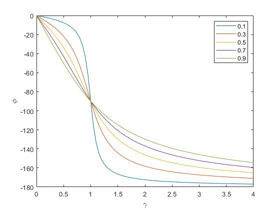

```matlab
phi = [];
for i = 1:length(zeta)
    phi(i,:) = -atan2((2*zeta(i).*r),(1-r.^2));
end

plot(r,phi*180/pi)
xlabel('\gamma')
ylabel('\phi')
legend('0.1','0.3','0.5','0.7','0.9')
```

## 5.4. Resonance in Second-Order Systems

- When the input frequency $\Omega$ approaches a specific value, the amplitude of the output response becomes maximal.
- This phenomenon is called resonance.

**What is Resonance?**

The resonance frequency $\Omega_r$ is the input frequency that maximizes the amplitude of the steady-state response:

$$ A = \left| H(j\Omega) \right| = \frac{1}{ \sqrt{ (1 - \gamma^2)^2 + 4\zeta^2 \gamma^2 } }, \quad \gamma = \frac{\Omega}{\omega_n} $$

To find the resonance frequency, minimize the denominator:

$$ (1 - \gamma^2)^2 + 4\zeta^2 \gamma^2 $$

Taking derivative with respect to $\gamma$ and solving yields:

$$ \gamma_r = \sqrt{1 - 2\zeta^2} \quad \Longrightarrow \quad \Omega_r = \omega_n \sqrt{1 - 2\zeta^2} $$

**Key Points**

- Resonance frequency:

$$ \Omega_r = \omega_n \sqrt{1 - 2\zeta^2} $$

- Natural frequency:

$$ \omega_n $$

- For small damping ($\zeta \ll 1$), $\Omega_r \approx \omega_n$
- Resonance frequency is generally different from natural frequency, but they often are close enough

**Physical Meaning**

- The system amplifies input signals near $\Omega_r$.
- If damping $\zeta$ is low, this amplification can be very large, leading to large oscillations.

```matlab
from IPython.display import YouTubeVideo
YouTubeVideo('CzJ8EKi11pU', width = "560", height = "315")
```

[video not shown]

```matlab
from IPython.display import YouTubeVideo
YouTubeVideo('Mqt_Amkw-0Y', width = "560", height = "315")
```

[video not shown]

```matlab
from IPython.display import YouTubeVideo
YouTubeVideo('TYA8C85CdCc', width = "560", height = "315")
```

[video not shown]

```matlab
%%javascript
$.getScript('https://kmahelona.github.io/ipython_notebook_goodies/ipython_notebook_toc.js')
```